## Tercera parte de la entrega

En la tercera parte de la entrega se nos pide analizar cuantas veces aparecen los verbos de un `head` (cabecera del texto) en su respectivo texto y lo mismo con el `summary` (resumen del texto). Es importante destacar que contamos la frecuencia de verbos únicos, es decir, si el verbo ser se repite 20 veces en el texto, y hay 2 verbos ser en el head, la **frecuencia** total del verbo ser es 20, ya que solo se cuenta uno. Lo mismo aplica a summary.

Explicado esto procedemos a detallar el código:

Para empezar, debemos de **importar** código de otros archivos para poder mostrar los tests de determinadas funciones para hacer más legible el rmd. Lo hacemos de usando la función `source()` e importando el archivo `test_train_analysis.R`.

Como vamos a estar trabajando con corpus y parseandolos, importamos las librerías de `quanteda` y `spacyr.` Importamos un corpus leyendo el archivo `spanish_train.qcorpus.rds`, e inicializamos el `spacy_parse` con el modelo español `spacy_initialize("es_core_news_sm")`

Ahora procedemos a parsear el corpus que importamos. Parsear (con la función `spacy_parse()`) sirve para tokenizar el corpus dado y poder hacer un mejor análisis de él. El problema de hacer un `spacy_parse()` es que los tiempos de procesado se pueden hacer muy largos. Por ello, vamos a ir guardando cada procesado de datos en un `RDS`, que es un **formato de almacenamiento** en R que permite **guardar** un objeto R en un archivo binario compacto, utilizado para preservar y cargar datos entre sesiones de trabajo.

Por ello definimos una estructura `if-else` que lo que hace es cargar el el corpus ya parseado de un archivo RDS `words_title.rds` el cual contiene las palabras de todos los títulos de todos los textos (if), o en caso de no tenerlo hacer el parseado por su cuenta (else).

Luego creamos un `dataframe` llamado `verbs_title` que contenga todos los **doc_id** (texto al que pertenece el verbo) y su **lemma** (su forma en infinitivo).

**Veamoslo:**

```r
head(verbs_title)
```

```
##    doc_id     lemma
## 2   text1     decir
## 4   text1  peligrir
## 28  text4 reconocer
## 40  text5  inspirar
## 57  text6     parar
## 70  text7     tener
```

Hacemos exactamente lo mismo con **summary** y nos queda lo siguiente:

```r
head(verbs_summary)
```

```
##    doc_id    lemma
## 13  text1 advertir
## 17  text1 invertir
## 26  text1    tener
## 28  text1  detener
## 48  text2   lanzar
## 52  text2 disparar
```

Exactamente la misma estructura `if-else` es definida para los `texts`.

```r
head(verbs_text)
```

```
##    doc_id    lemma
## 3   text1  recibir
## 15  text1 terminar
## 32  text1    decir
## 47  text1 recortar
## 50  text1   llegar
## 61  text1    hacer
```

Ahora vamos a definir la función `verbs_create_list`. Esta función crea una lista donde **cada elemento** corresponde a un ID de corpus `(corpus_ids)` y contiene los verbos en infinitivo `(lemmas)` asociados a ese ID o un vector vacío.

A continuación una estructura `if-else` parecida a la anterior es definida, donde vamos a verificar si existen **RDS** llamados `list_verbs_titles.rds` y `list_verbs_summary.rds`. En el caso de que no existan, y por tanto no se puedan cargar aplicamos la función `verbs_create_list` sobre **verbs_title** y  
**verbs_summary** acompañados de **corpus_ids**. El resultado de aplicar esta función a ambas sería lo siguiente:

```r
head(list_verbs_titles)
```

```
## $text1
## [1] "decir"    "peligrir"
##
## $text2
## character(0)
##
## $text3
## character(0)
##
## $text4
## [1] "reconocer"
##
## $text5
## [1] "inspirar"
##
## $text6
## [1] "parar"
```

```r
head(list_verbs_summary)
```

```
## $text1
## [1] "advertir" "invertir" "tener"    "detener"
##
## $text2
## [1] "lanzar"    "disparar"  "dispersar"
##
## $text3
## character(0)
##
## $text4
## [1] "reconocer" "forzar"    "subir"     "pagar"
##
## $text5
## [1] "infectar" "tener"    "tener"    "ver"
##
## $text6
## [1] "escapar"   "convertir" "competir"  "seguir"
```

Lo mismo con `verbs_text`:

```r
print(list_verbs_text[1:4])
```

```
## $text1
## [1] "recibir"  "terminar" "decir"    "recortar" "llegar"   "hacer"    "juntar"
## [8] "proteger"
##
## $text2
##  [1] "hindúes"   "gritar"    "tener"     "decir"     "producir"  "volver"
##  [7] "empezar"   "lanzar él" "resultar"  "arrestar"  "evitar"    "liderarar"
##
## $text3
## [1] "ver"     "mostrar" "buscar"  "perder"  "ganar"   "crear"
##
## $text4
## [1] "restar"    "decir"     "afectar"   "restar"    "demandar"  "organizar"
## [7] "demandar"
```

Ahora, como bien dice el enunciado, tenemos que coger los verbos **únicos** tanto de `titles` como de `summary`, ya que no queremos verbos repetidos, solo los queremos una vez. Para esto definimos una función `make_unique()`, que, como se intuye por el nombre, **elimina** duplicados en cada elemento no vacío de una lista, manteniendo solo valores **únicos** en cada sublista.

Si nos fijamos en `list_verbs_summary`, en **text_5** hay dos veces el verbo, tener, así que usando la función anterior, esto no debería aparecer. Veamoslo:

```r
head(list_verbs_summary_unique)
```

```
## $text1
## [1] "advertir" "invertir" "tener"    "detener"
##
## $text2
## [1] "lanzar"    "disparar"  "dispersar"
##
## $text3
## character(0)
##
## $text4
## [1] "reconocer" "forzar"    "subir"     "pagar"
##
## $text5
## [1] "infectar" "tener"    "ver"
##
## $text6
## [1] "escapar"   "convertir" "competir"  "seguir"
```

Como vemos, solo aparece **tener** una vez.

Ahora llegamos al núcleo del proyecto, contar cuantas veces aparecen verbos del título y resumen en sus textos respectivos. Para ello definimos una nueva función llamada `freq_verbs`.

La función `freq_verbs` calcula la **frecuencia** de verbos en un conjunto de verbos del texto. Toma tres argumentos: `text_list` (lista de verbos en los textos), `list_comp` (lista de verbos a comparar) y `corpus_ids` (identificadores de los textos). Inicializa un vector `freq` vacío con la misma longitud que `list_comp` y asigna los `corpus_ids` como **nombres**. Luego, recorre cada texto y cuenta cuántas veces los verbos de la lista `list_comp` aparecen en el texto correspondiente. La frecuencia total de cada verbo se **guarda** en el vector `freq`, que se devuelve al final.

Aplicamos esta función y obtenemos las frecuencias de los verbos de cada `title` en su texto y de cada `summary` en su texto.

Veamos un ejemplo de como queda:

```r
freq_verbs_titles[50:100]
```

```
##  text50  text51  text52  text53  text54  text55  text56  text57  text58  text59
##      14       0       0       0       4       0       1       6       2      13
##  text60  text61  text62  text63  text64  text65  text66  text67  text68  text69
##       4       0       0       1       0       0       0       0       0       0
##  text70  text71  text72  text73  text74  text75  text76  text77  text78  text79
##       0       0       6       0      11       0       6       1       0       0
##  text80  text81  text82  text83  text84  text85  text86  text87  text88  text89
##       7       0       4       0      14       0       0       0       0       0
##  text90  text91  text92  text93  text94  text95  text96  text97  text98  text99
##       0       0       0       0       1       2       0       0       8       1
## text100
##       1
```

```r
freq_verbs_titles[50:100]
```

```
##  text50  text51  text52  text53  text54  text55  text56  text57  text58  text59
##      14       0       0       0       4       0       1       6       2      13
##  text60  text61  text62  text63  text64  text65  text66  text67  text68  text69
##       4       0       0       1       0       0       0       0       0       0
##  text70  text71  text72  text73  text74  text75  text76  text77  text78  text79
##       0       0       6       0      11       0       6       1       0       0
##  text80  text81  text82  text83  text84  text85  text86  text87  text88  text89
##       7       0       4       0      14       0       0       0       0       0
##  text90  text91  text92  text93  text94  text95  text96  text97  text98  text99
##       0       0       0       0       1       2       0       0       8       1
## text100
##       1
```

Ahora viene la parte de los **testeos** para confirmar que lo que hemos hecho es correcto. Para realizarlo, vamos a crear otra función `test_freq_verbs`.

La función `test_freq_verbs` prueba la función `freq_verbs` en un **subconjunto** de documentos, calculando la frecuencia de verbos en títulos y resúmenes. Muestra los verbos coincidentes entre texto, título y resumen, y sus frecuencias correspondientes para cada documento.

Veamos el testeo:

```r
test_freq_verbs(list_verbs_text, list_verbs_title_unique, list_verbs_summary_unique, corpus_ids)
```

```
##
## ------ Testing freq_verbs Function ------
##
## Document ID: text56
## Text Verbs: saber desafeír responder animar realizar seguir
##
## Title Verbs: saber
## Matched Title Verbs:
##  saber
## Matched Count (Titles): 1
##
## Matched Verbs:
##
## Matched Count (Summaries): 0
##
## Document ID: text57
## Text Verbs: desconocer dar recetar mandar recibir enfermar deber hacer esparcir aumentar temer interesar admitir fracasar detectar confirmar necesitar requerir decir pedir hacer solicitar monitorear detectar apoyar desarrollar designar dirigir combatir anunciar adelantar intentar calmar estabiliz…
##
## Title Verbs: fracasar combatir dejar
## Matched Title Verbs:
##  fracasar, combatir, dejar
## Matched Count (Titles): 6
##
## Matched Verbs:
##  contagiar
## Matched Count (Summaries): 5
##
## Document ID: text58
## Text Verbs: estar participar participar esperar producir estar alcanzar él decir decidir viajar pasar tratar resolver interesar viajar asistir
##
## Title Verbs: viajar
## Matched Title Verbs:
##  viajar
## Matched Count (Titles): 2
##
## Matched Verbs:
##  participar
## Matched Count (Summaries): 2
##
## Document ID: text59
## Text Verbs: causar explorar encontrar decidir oponer él ordenar detener morir pasar gobernar dejar descubrir creer pertenecer interesar analizar descubrir asesinar tener conducir pertenecer desconocer desaparecer hacer extinguir surgir saltar contraer llevar ocurrir comenzar generar desaparecer t…
##
## Title Verbs: desaparecer dejar combatir
## Matched Title Verbs:
##  dejar, desaparecer, combatir
## Matched Count (Titles): 13
##
## Matched Verbs:
##  causar, desaparecer, persistir
## Matched Count (Summaries): 19
##
## Document ID: text60
## Text Verbs: jurar mandar insistir marcar tener definir él querer decir sorprender saber cultivar dejar él centrar interesar tocar construir encontrar reconocer detener proteger librar llegar establecer abrir tuitear temer interferir tornir llevar lograr opinar preferir pronunciar él -alegar acaba…
##
## Title Verbs: esperar
## Matched Title Verbs:
##  esperar
## Matched Count (Titles): 4
##
## Matched Verbs:
##  tener, meter
## Matched Count (Summaries): 11
```

Gráficamente podemos **visualizar** esto. Primero, vamos a crear una **tabla** con las frecuencias de los resumenes y hacer un `bar_plot`. Quedando lo siguiente:

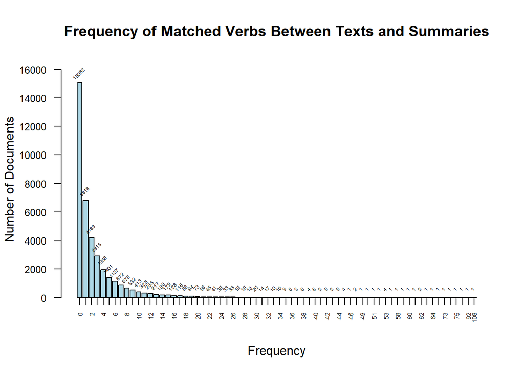

Y la **tabla de frecuencias**:

```r
freq_table1
```

```
## freq_verbs_summary
##     0     1     2     3     4     5     6     7     8     9    10    11    12
## 15062  6818  4189  2915  1958  1401  1137   872   678   532   413   325   285
##    13    14    15    16    17    18    19    20    21    22    23    24    25
##   217   180   179   128   116    88    94    73    56    45    41    39    33
##    26    27    28    29    30    31    32    33    34    35    36    37    38
##    33    19    19    13    20    14    17    10    10     9     6     3     6
##    39    40    41    42    43    44    45    46    47    49    50    51    52
##     4     8     2     5     2     5     4     1     2     1     1     1     1
##    53    56    58    59    60    61    62    63    64    67    73    74    75
##     4     1     1     1     1     1     2     1     1     1     1     1     1
##    89    92   108
##     1     1     1
```

También podemos hacer esto con los **títulos** y quedaría lo siguiente:

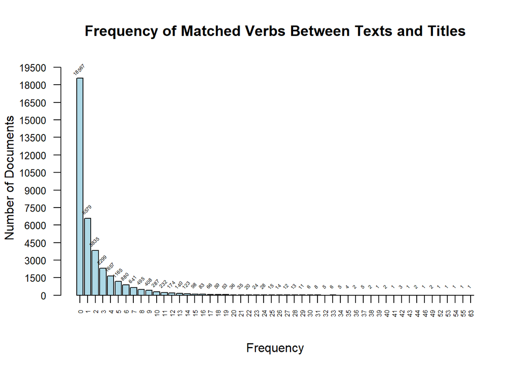

Con su **tabla de frecuencias**:

```r
freq_table2
```

```
## freq_verbs_titles
##     0     1     2     3     4     5     6     7     8     9    10    11    12
## 18567  6579  3835  2299  1657  1165   880   641   495   408   287   232   174
##    13    14    15    16    17    18    19    20    21    22    23    24    25
##   140   123    98    83    66    59    53    36    35    20    24    28    15
##    26    27    28    29    30    31    32    33    34    35    36    37    38
##    14    12    13    11     6     8     5     6     5     4     2     5     2
##    39    40    41    42    43    44    46    49    52    53    54    55    63
##     1     2     1     3     1     2     1     2     1     1     1     1     1
```

Ahora hagamos un testeo para una determinada **frecuencia de summary**. Para ello, creamos la función `test_specific_frequency_summary`.

La función `test_specific_frequency_summary` busca documentos con una frecuencia **específica** de verbos en los **resúmenes**, muestra detalles de los verbos coincidentes entre texto y resumen, y presenta el **número de coincidencias por documento**. Si no hay documentos con esa frecuencia, informa que no se encontraron coincidencias.

Hagamos un test, por ejemplo, con los de frecuencia **43**:

```r
test_specific_frequency_summary(43, freq_verbs_summary, list_verbs_text, list_verbs_summary_unique, corpus_ids)
```

```
##
## === Testing for Frequency: 43 ===
##
## Document ID: text5524
## Text Verbs:
##  pasar, regresar, preguntar, interesar, vivir, recordar, recordar, contar, presentar, casar, unir, acercar, querer, despertar, provocar, contar, hacer, tener, ir yo, ganar, llamar, contar, pasar, pedir, hacer, indicar, ayudar, ver, ir, avisar, acercar, contar, llevar, ayudar, empezar, hacer, avis…
##
## Summary Verbs:
##  dar, decir, atender
## Matched Verbs (Summaries) with Counts:
##   decir ( 26 ),   dar ( 15 ),     atender ( 2 )
## Matched Count (Summaries): 3
##
## Document ID: text10317
## Text Verbs:
##  vivir, luchar, lograr, resultar, acostar, transmitir, renunciar, convencer, volver, sugerir, usar, onlinar, renunciar, llegar, gustar, gustar, intrigar, pensar, conocer, ir, tomar, sentar, hablar, suponer, contar, contar, hablar, parecer, interesar, saber, sentir, hacer, pensar, valer, empezar, …
##
## Summary Verbs:
##  esperar, encontrar, venir, tener, suceder
## Matched Verbs (Summaries) with Counts:
##   tener ( 30 ),   venir ( 1 ),    encontrar ( 10 ),   esperar ( 1 ),      suceder ( 1 )
## Matched Count (Summaries): 5
```

Podemos hacer lo mismo con los **títulos**, por ejemplo, con los que tengan **30** frecuencias y queda lo siguiente:

```r
test_specific_frequency_titles(30, freq_verbs_titles, list_verbs_text, list_verbs_title_unique, corpus_ids)
```

```
##
## === Testing for Frequency: 30 ===
##
## Document ID: text801
## Text Verbs:
##  significar, rendir, ver, mirar, pasar, detener él, saludar, resultar, olvidir, llenar, sentar, comer, soler, realizar, empezar, escribir, venir, estereotipar, ir, volver, trabajar, balancear, far, hacer, llamar, hacer, parecer, llenar, hacer, descubrir, parar, saber, estudiar, significar, produc…
##
## Title Verbs:
##  lograr, hacer, ayudar
## Matched Verbs (Titles) with Counts:
##   hacer ( 25 ),   lograr ( 1 ),   ayudar ( 4 )
## Matched Count (Titles): 3
##
## Document ID: text1750
## Text Verbs:
##  especializar, tener, motivar, publicar, oir, escuchar, trabajar, tener, pasar, hablar, tener, poner, incluir, contribuir, escribir, traducir, hablar, ocurrir, interesar, llegar, crié, encontrar, pasar, poner, pensar, gastar, conseguir yo, emplearar, llamar, encantar, entrar, salir, tener, tener,…
##
## Title Verbs:
##  tener, pedir, trabajar
## Matched Verbs (Titles) with Counts:
##   tener ( 27 ),   trabajar ( 3 )
## Matched Count (Titles): 2
##
## Document ID: text8043
## Text Verbs:
##  escribir, significar, regresar, estar, evitar, parecer, suceder, tener, adaptar él, presentar, ver, continuar, ver, imponer, ver, comunicar, implementir, asimilar, responder, interesar, conversar, aceptar, colaborar, vivir, tener, trabajar, concentrar, publicar, editar, empezar, hablar, user, ha…
##
## Title Verbs:
##  tener, entrevistar
## Matched Verbs (Titles) with Counts:
##   tener ( 30 )
## Matched Count (Titles): 1
##
## Document ID: text9447
## Text Verbs:
##  nacer, llevar, tener, saber, nacer, adoptar, nacer, hacer, sospechar, decir, adoptar, decir, llevar, tener, conocer, tener, aprender, hablar, interesar, ir, practicar, tener, tener, conducir, poner, decir, cambiar, hacer, tener, obtener, acceder, requerir, decir, necesitar, comenzar, recordar, d…
##
## Title Verbs:
##  descubrir, tener
## Matched Verbs (Titles) with Counts:
##   tener ( 25 ),   descubrir ( 5 )
## Matched Count (Titles): 2
##
## Document ID: text12070
## Text Verbs:
##  encerrar, incluir, generar, ordenar, hacer, partir, empezar, erigir, asegurar, sufrir, frenar, trabajar, querer, construir, saber, admitir, denunciar, crear, restringir, dificultar, limitar, condenar, planear, construir, frenar, tener, bastar, construir, explaya, hablar, enfrentar, explicar, con…
##
## Title Verbs:
##  bastar, construir, hacer
## Matched Verbs (Titles) with Counts:
##   hacer ( 11 ),   construir ( 17 ),   bastar ( 2 )
## Matched Count (Titles): 3
##
## Document ID: text16974
## Text Verbs:
##  sobrevivir, formar, sentir, pensar, sentir, tener, vivir, ver, costar, salir, decir, sentir él, decir, sentir, resultar, reflejar, tener, autoseleccionar, venir, ayudar, atraer, sentir, decir, sentir, plantear, decir, sentir, admitir, sentir, necesitar, enfatizar, preguntar, sentir, dar, experim…
##
## Title Verbs:
##  sentir
## Matched Verbs (Titles) with Counts:
##   sentir ( 30 )
## Matched Count (Titles): 1
```